# Monte Carlo Power Analysis for Indirect Effects

### Monte Carlo Power Analysis for Indirect Effects

Written by Alexander M. Schoemann ( Contact ), Aaron J. Boulton, & Stephen D. Short

| Model | One Mediator |
| --- | --- |

| Objective | Set N, Find Power |
| --- | --- |

| Sample Size (N) |  |
| --- | --- |

| # of Replications |  |
| --- | --- |

| Monte Carlo Draws per Rep |  |
| --- | --- |

| Random Seed |  |
| --- | --- |

| Confidence Level (%) |  |
| --- | --- |

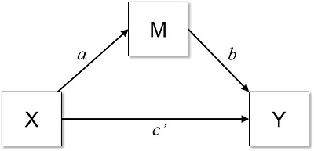

| Input Method | Correlations |
| --- | --- |

|  | X | M | Y |
| --- | --- | --- | --- |
| X | 1.00 |  |  |
| M |  | 1.00 |  |
| Y |  |  | 1.00 |
| Std. Deviation |  |  |  |

#### Instructions

To use this app, follow these steps:

**1. Select Model.** The user should first select the mediation model containing the indirect effect(s) of interest. Models may be selected in the drop-down menu in the left-most column of the app. Note that when a different mediation model is selected, the model graphic and input-value sections in the middle column will be altered.

**2. Select Objective.** Once the desired model is chosen, the user should select the objective of the power analysis. Two options are permitted. The user can choose to estimate the statistical power for a given model and sample size ("Set N, Find Power"), or the user may choose to estimate the required sample size for a given model and desired level of power ("Set Power, Vary N"). Once an option is selected, an additional set of options will appear below that require the user's attention.

For the **Set N, Find Power** option:

**Select Sample Size.** The sample size (N) the user wishes to obtain a power estimate for should be entered in the designated box.

For the **Set Power, Vary N** option:

**Select Target Power.** The level of statistical power the user wishes to determine a sufficient sample size (N) for should be entered in the designated box.

**Select Minimum N.** The lowest sample size that the user wishes to compute a power estimate for.

**Select Maximum N.** The largest sample size that the user wishes to compute a power estimate for.

**Select Sample Size Steps.** The increments in sample size the user wishes to compute power estimates for that range between the selected minimum and maximum sample sizes.

**3. Select Number of Power Analysis Replications.** The user must select the number of replications computed in the power analysis. For each replication, a dataset is generated for the selected mediation model and the Monte Carlo method for computing confidence intervals is used to determine whether the indirect effect(s) of interest is significantly different from zero. The power estimate(s) is calculated by dividing the number of replications in which the indirect effect(s) of interest is significantly different from zero by the total number of replications.

**4. Select Number of Monte Carlo Draws per Replications.** For each replication of a given power analysis, the Monte Carlo method for computing indirect effect confidence intervals requires a set number of random draws from the distribution of regression coefficients that constitute the indirect effect(s) of interest. For example, if the user request 5000 Monte Carlo draws per rep for a single mediator model, the a and b coefficients will be sampled from their joint probability distribution 5000 times. These draws are used to calculate a confidence interval for each indirect effect in a given model.

**5. Select Random Seed.** The user may select a random seed for initiation of the random number generator used in the application. Identical results can be obtained if the same seed is select in conjunction with the sample analysis options and model input values.

**5. Select Confidence Level.** Width of the Monte Carlo confidence intervals computed for each indirect effect of interest. The default option is 95%.

**6. Input Model Values.** To generate data for the select model, the user must enter values that allow the application to compute a covariance matrix for all variables in the model. Currently, the only input method supported is for users to enter the correlations between all variables in a correlation matrix as well as the variable standard deviations. Additional methods may become available in the future.

**6. Initiate Power Analysis.** Once all options and model input values have been specified, the user can press the "Calculate Power" button to initiate the Monte Carlo power analysis. If any options or input values have been entered incorrectly, an error message will appear below the button. If all values have been entered correctly, a progress bar will appear at the top of the page, indicating the power analysis has begun.